# Biodiversity and Environmental Equity

Kang

5/31/2022

## Introduction

In this research, we are interested in whether vulnerable people are exposed in lower biodiversity environment. Usually, in previous studies, we often see wealthier people stay in higher biodiversity area. There are two potential reasons. First, they make the area biodiversity-higher, for example, by buying more uncommon plant species or building larger garden with more expensive species. Another possible reason is that richer people can afford buying houses in high-biodiversity areas. As if you see the pictures of some tourism islands, rich people’s houses are usually located in green surroundings. Those studies usually pay more attention to people’s income; in other words, the “vulnerable people” in those previous studies refer to people who are not so rich. While in this study, we are going to expand the social-economic variables to other communities, like the elder, children, and women. We want to if they are suffering potentially from a low biodiversity environment.

From a perspective of writing an article, of course we hope the results are positive, namely that vulnerable people are related to lower biodiversity area - though we don’t like it happening in the real world. However, just for your record, the current results are negative. Seems that only a few of our target variables (for example, the proportion of women, the elder, or people with lower income) are significantly related with biodiversity indexes.

Anyway, I have tidy the code, and made a GitHub project repo for our study. We are going to put all our analysis and documents on GitHub and Google docs. In this doc, I am just going to show you the basic framework of my analysis. I am going to revise the analysis, but every future revision will be based on this one. So you may want to understand the details of this first analysis.

## Method and Results

As the data I shared with you, I have investigated about 150 plots (20 meters by 20 meters for each plot) in Kyoto City. I collect the species and number of the trees and shrubs. So that I can calculate the biodiversity indexes (including richness, Shannon Index, Simpson Index, and evenness) of each plot. **The biodiversity indexes are our Y (response variables).**

**Besides, for each plot, I also have two arrays of X (explainable variables).** The first are environmental variables, like land use and land cover. The second are related to our target vulnerable communities, including the land price (to indicate residents’ income), the population and the proportion of the elder / women / children etc.

You have already seen the maps of plot distribution on the poster I send you before. There are also the maps for the proportion of the elder (most of the high-elder-proportion areas are in the middle to the east of the city) and the distribution of the land price. **Now that we have Y and X, the next step is to analyze the relationship between them.** As the first step, we want to see the pairwise correlation between the Ys and the Xs. Here is the correlation results - you have also read that on the poster maybe. The cells with a “X” indicate that they have no significant correlation. The cells without “X”s and with blue numbers means there is a positive relationship (the higher the X, the higher the Y), while those with red numbers indicate a negative relationship. So the conclusion is that, most of the Xs are not correlated with the Ys. And beyond our expectation, the higher proportion of the elder (Pop>65 and Pop>75) are positively correlated with biodiversity indexes - it means the elder live in the area with higher biodiversity. For land use, multi-family houses and (“MultiFamily”) and commercial or industrial land use (“CommerIndust”) are negatively related to biodiversity indexes. **Do you have any idea or guess about that?**

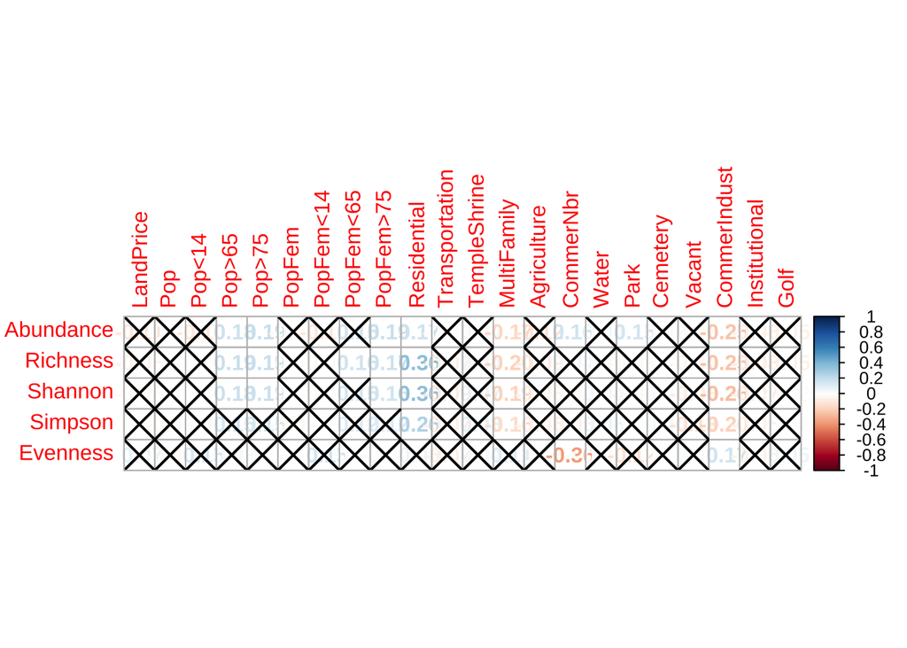

```r
GetCorrplot(qua.all[kIndex], qua.all[c("land_price", kPopFac, kLandCover)],
            x.name = c("Abundance", "Richness",
                       "Shannon", "Simpson", "Evenness"),
            y.name = c("LandPrice",
                       "Pop", "Pop<14", "Pop>65", "Pop>75",
                       "PopFem", "PopFem<14", "PopFem<65", "PopFem>75",
                       "Residential", "Transportation", "TempleShrine",
                       "MultiFamily", "Agriculture", "CommerNbr",
                       "Water", "Park", "Cemetery", "Vacant",
                       "CommerIndust", "Institutional", "Golf"))
```

Then, I used multiple linear regression for further analysis of the relationship between the biodiversity indexes and the explanatory variables. I did that for each biodiversity indexes respectively. We have a lot of Xs (explanatory variables) here, and we can’t put them all into the regression model. So I used a method to choose the “best model”, which goes like the following statement. Say we have a Y, and X1, X2, X3, X4. For the first regression, we only use Y and X1 in the regression; for the second model, we use Y and X1 and X2 … then we compare a model performance indicator of all the models, and get the model performing best. One example of the best model selecting process is shown as the following figure. It determines what are the best explanatory variables for richness regression. As you can see, we tried only Intercept and “residential” (= residential land use) first, then we add other variables. In this process, the adjr2 (adjusted r-square, the model performance indicator mentioned above) goes up. Finally, we decide to use the four explanatory variables for richness regression model: pop_prop_75_up, residential, multi_family_residential, commercial_industrial.

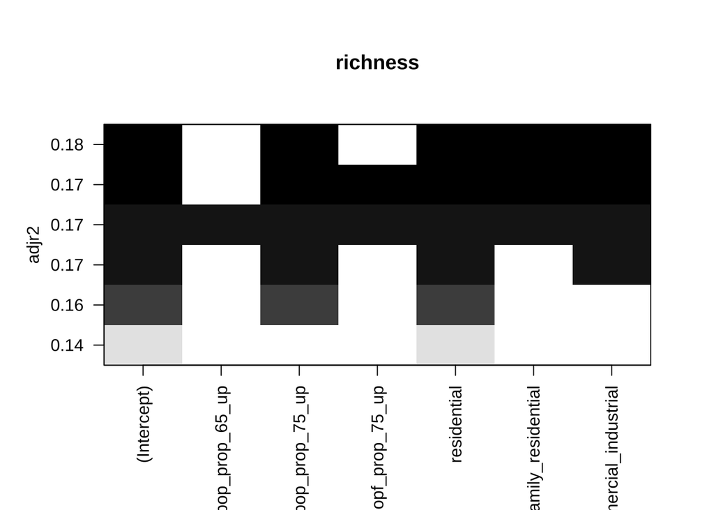

```r
GetRegSubset(qua.all, "richness")
```

And the estimates and p-values of those variables in the richness regression model are show in the following table.

```r
best.richness
```

```
##                   variable result p_mark
## 1           pop_prop_75_up   0.14
## 2              residential   4.32    ***
## 3 multi_family_residential  -2.82
## 4    commercial_industrial  -4.51
```

Similarly, we can get the results for Shannon Index, Simpson Index, and evenness.

```r
best.shannon
```

```
##                   variable result p_mark
## 1           pop_prop_75_up   0.02
## 2              residential   0.56     **
## 3 multi_family_residential  -0.39
## 4    commercial_industrial  -0.60      *
```

```r
best.simpson
```

```
##                   variable result p_mark
## 1           pop_prop_75_up   0.00
## 2              residential   0.12      *
## 3 multi_family_residential  -0.10
## 4    commercial_industrial  -0.12
```

```r
best.evenness
```

```
##                   variable result p_mark
## 1           pop_prop_75_up   0.00
## 2              residential   0.04
## 3 multi_family_residential   0.07      *
## 4    commercial_industrial   0.11     **
```

P.S. I have some ideas, but before that, I am quite interested in your thoughts about that ; )